# Test Parallel

davegoblue

May 3, 2016

## Overview and Background

The parallel package in R allows for nice improvements in run time. So far, I have been using 3 workers with Windows (number of threads minus 1), but I am curious more generally about the gains driven by parallel. This program is a first effort to test speed vs. number of clusters.

Among the more interesting findings so far, based on an intel i7 with 2 physicial cores and 4 logical cores:

- For a function that is primarily computational (very little work to split/integrate the jobs), there is roughly a 50% gain for moving from 1 sequential cluster to 2 parallel clusters, with modest (5%-10% in aggregate) improvements from moving to 3+ clusters
- For a function that has significant work to split/integrate the jobs (e.g., randomForest), there appears to be some fixed cost to moving to parallel, and there is a lesser gain when moving to just two clusters, and correspondingly more gain when moving to three clusters
- Further study on larger randomForests (or similar) may be interesting to get a better feel for the trade-offs induced by any fixed cost of splitting/integrating

## Analysis

The analysis includes the following:

- Grab some background data about the machine and call the parallel and doParallel libraries
- Create a “time waster” function that is almost entirely computational time
- Time waster function is run sequentially
- Time waster function is run in parallel, with 3 clusters each doing the same work as sequential (3x total work)
- Time waster function is run “properly” in parallel, doing in aggregate 100% of the sequential work
- Time waster function to investigate parallel by splitting each of the two dimensions passed
- Time waster function is run in parallel (aggregate 100% of sequential workload) using 1-8 parallel clusters
- Random Forest data is loaded, cleaned, and prepped
- Random Forest run on 9 predictors, sequentially
- Random Forest run on 9 predictors, with 2 parallel clusters
- Random Forest run on 9 predictors, with 3 parallel clusters
- Accuracy comparisons for all Random Forests on 9 predictors (CV vs. Boot, Sequential vs. 2-3 Parallel)
- Random Forest run on ~50 predictors, sequentially and then with 2-3 clusters

#### *Background and Basic Setup*

First, the parallel and doParalel libraries are called, and information about the specific setup is printed:

```r
library(parallel)
library(doParallel)
nLogical <- detectCores() ## defaults to logical=TRUE
nCore <- detectCores(logical=FALSE) ## will only find physical cores

print(paste0("This set-up has ",nLogical," cores, with ",nCore," being physical cores."))
```

```
## [1] "This set-up has 4 cores, with 2 being physical cores."
```

#### *Time Waster Function Declaration*

Next, a time-waster function is set-up. This function is designed to repeatedly do the maths on a vector, then to return the final vector. It is purely to get the CPU cranking; there is no other purpose to the function:

```r
timeWaster <- function(vecLen=factorial(8), nRuns=factorial(8)) {
    vecTemp <- rep(0, vecLen) ## Create numeric vector
    vecMeans <- rep(0, nRuns) ## Create the storage vector

    for (intCtr in 1:nRuns) {
        vecTemp <- vecTemp * rnorm(vecLen)
        vecTemp <- vecTemp + rnorm(vecLen)
        vecMeans[intCtr] <- mean(vecTemp)
    }

    return(vecMeans)
}
```

#### *Time Waster (Sequential)*

First, the time waster function is called sequentially (normally) for a timing benchmark:

```r
baseTime <- proc.time()

temp <- timeWaster()
str(temp)
```

```
##  num [1:40320] 0.00287 -0.01283 0.00355 0.00855 0.02212 ...
```

```r
summary(temp)
```

```
##       Min.    1st Qu.     Median       Mean    3rd Qu.       Max.
## -0.5087000 -0.0145900 -0.0002085 -0.0002205  0.0141500  0.6104000
```

```r
seqTime <- proc.time() - baseTime

print("Ran sequentially: Time taken")
```

```
## [1] "Ran sequentially: Time taken"
```

```r
print(seqTime)
```

```
##    user  system elapsed
##  274.39    7.20  285.93
```

#### *Time Waster (Parallel Baseline, 3x Work)*

Next, the parallel processing routine is called with the following parameters:

- The number of clusters will be the number of logical clusters minus 1 (3 total on my machine)
- Each cluster will run the same timeWaster() function; importantly, there is no splitting up of the workload, so the 3 parallel clusters will do (in aggregate) 3 times as much work
- Processing will run by way of foreach() %dopar% with .combine=c (concatenate it all in to one jumbo vector)

The intent of the above is to establish a baseline for the inefficiencies introduced by running in parallel. The machine needs to create its clusters, parse out work to them, and integrate their results. This is sort of a fixed cost that will (likely) never be overcome.

```r
baseTime <- proc.time()

nPars <- nLogical - 1 ## Default is to save 1 logical core for other processing
clCores <- makeCluster(nPars)
registerDoParallel(clCores)

temp <- foreach(parCtr=1:nPars, .combine=c) %dopar% {
    timeWaster()
}

stopCluster(clCores)
registerDoSEQ()

str(temp)
```

```
##  num [1:120960] -0.00297 0.00436 -0.00907 -0.02219 -0.0166 ...
```

```r
summary(temp)
```

```
##       Min.    1st Qu.     Median       Mean    3rd Qu.       Max.
## -0.9626000 -0.0143500  0.0000263  0.0000966  0.0144500  1.4020000
```

```r
parTime <- proc.time() - baseTime

print("Ran in parallel: Time taken")
```

```
## [1] "Ran in parallel: Time taken"
```

```r
print(parTime)
```

```
##    user  system elapsed
##    0.09    0.07  395.82
```

The parallel run is doing 300% of the work in ~140% of the time, suggestive of just over a 50% decrease in elapsed time per unit of work.

#### *Time Waster (Parallel, Same Work as Sequential)*

Next, the parallel process is run more properly, with nRuns divided by the number of clusters. As the same total volume of work will be completed, the time comparison will be more interesting:

```r
baseTime <- proc.time()

nPars <- nLogical - 1 ## Default is to save 1 logical core for other processing
clCores <- makeCluster(nPars)
registerDoParallel(clCores)

## Yes, the below is mathematically a mess if you want timeWaster() to do "real" analysis!
temp <- foreach(parCtr=1:nPars, .combine=c) %dopar% {
    timeWaster(nRuns=ceiling(factorial(8)/3))
}

stopCluster(clCores)
registerDoSEQ()

str(temp)
```

```
##  num [1:40320] 0.009653 -0.000698 -0.008434 0.011501 0.001038 ...
```

```r
summary(temp)
```

```
##       Min.    1st Qu.     Median       Mean    3rd Qu.       Max.
## -1.4870000 -0.0144300 -0.0000028  0.0000316  0.0144200  1.1000000
```

```r
parSameTime <- proc.time() - baseTime

print("Ran in parallel for same workload: Time taken")
```

```
## [1] "Ran in parallel for same workload: Time taken"
```

```r
print(parSameTime)
```

```
##    user  system elapsed
##    0.04    0.00  133.29
```

The parallel process is now doing 100% of the sequential workload in ~45% of the sequential time.

#### *Time Waster (Parallel, Investigate Fixed Inefficiency)*

An additional question of interest is whether the parallel process has a “fixed” inefficiency or a scalable inefficiency. This can be assessed by putting the routine to work on jobs of various sizes. For example, we could try the following:

- Parallel has just been run for the defaults of vecLen=factorial(8), nRuns=factorial(8)/3 but 3 times
- Suppose we triple vecLen to be 3 * factorial(8) and see how the processing time scales
- Suppose we also triple nRuns to be factorial(8) run three times and see how the processing time scales

```r
## Run with triple vecLen
baseTime <- proc.time()

nPars <- nLogical - 1 ## Default is to save 1 logical core for other processing
clCores <- makeCluster(nPars)
registerDoParallel(clCores)

## Yes, the below is mathematically a mess if you want timeWaster() to do "real" analysis!
temp <- foreach(parCtr=1:nPars, .combine=c) %dopar% {
    timeWaster(vecLen=3*factorial(8), nRuns=ceiling(factorial(8)/3))
}

stopCluster(clCores)
registerDoSEQ()

str(temp)
```

```
##  num [1:40320] 0.000262 0.006583 -0.010139 0.007144 0.011703 ...
```

```r
summary(temp)
```

```
##       Min.    1st Qu.     Median       Mean    3rd Qu.       Max.
## -2.851e-01 -8.561e-03 -3.108e-05 -5.135e-05  8.566e-03  2.684e-01
```

```r
parTripLenTime <- proc.time() - baseTime

print("Ran in parallel for triple workload (due vecLen): Time taken")
```

```
## [1] "Ran in parallel for triple workload (due vecLen): Time taken"
```

```r
print(parTripLenTime)
```

```
##    user  system elapsed
##    0.03    0.01  400.36
```

This routine takes roughly triple the time and does roughly triple the work, suggestive that there is a scalable inefficiency more so than a fixed inefficiency.

We then run the same routine but for triple vecLen AND triple nRuns:

```r
## Run with triple vecLen and triple nRuns (each of three parallel doing full nRuns)
baseTime <- proc.time()

nPars <- nLogical - 1 ## Default is to save 1 logical core for other processing
clCores <- makeCluster(nPars)
registerDoParallel(clCores)

## Yes, the below is mathematically a mess if you want timeWaster() to do "real" analysis!
temp <- foreach(parCtr=1:nPars, .combine=c) %dopar% {
    timeWaster(vecLen=3*factorial(8), nRuns=ceiling(factorial(8)))
}

stopCluster(clCores)
registerDoSEQ()

str(temp)
```

```
##  num [1:120960] 0.00782 0.00194 0.00596 -0.0043 0.00225 ...
```

```r
summary(temp)
```

```
##       Min.    1st Qu.     Median       Mean    3rd Qu.       Max.
## -0.3567000 -0.0087320 -0.0000692 -0.0000720  0.0086340  0.3074000
```

```r
parNineTime <- proc.time() - baseTime

print("Ran in parallel for 9x workload (due triple vecLen and triple nRuns): Time taken")
```

```
## [1] "Ran in parallel for 9x workload (due triple vecLen and triple nRuns): Time taken"
```

```r
print(parNineTime)
```

```
##    user  system elapsed
##    0.07    0.01 1206.84
```

This routine does ~900% of the base parallel work and take ~900% of the base parallel processing time, again suggestive that (at least for how this function works) there are few economies of scale.

The above have all been cached so that we can next explore the impact of changing the number of clusters.

#### *Time Waster (Parallel with 1-8 clusters)*

```r
parNTestTime <- matrix(rep(proc.time(),8),nrow=8,byrow=TRUE)

for (nPars in 1:8) {
    baseTime <- proc.time()

    clCores <- makeCluster(nPars)
    registerDoParallel(clCores)

    ## Yes, the below is mathematically a mess if you want timeWaster() to do "real" analysis!
    temp <- foreach(parCtr=1:nPars, .combine=c) %dopar% {
        timeWaster(nRuns=ceiling(factorial(8)/nPars))
    }

    stopCluster(clCores)
    registerDoSEQ()

    print(paste0("After running in parallel with ",nPars," clusters"))
    str(temp)
    summary(temp)

    parNTestTime[nPars,] <- proc.time() - baseTime

    print(paste0("Ran in parallel for same workload and with ",nPars," parallel clusters: Time taken"))
    print(parNTestTime[nPars,])
}
```

```
## [1] "After running in parallel with 1 clusters"
##  num [1:40320] -0.006913 -0.014275 0.000597 0.009714 0.005168 ...
## [1] "Ran in parallel for same workload and with 1 parallel clusters: Time taken"
## [1]   0.00   0.01 275.16     NA     NA
## [1] "After running in parallel with 2 clusters"
##  num [1:40320] -0.0027 0.00374 -0.00665 0.00615 0.00717 ...
## [1] "Ran in parallel for same workload and with 2 parallel clusters: Time taken"
## [1]   0.05   0.00 153.61     NA     NA
## [1] "After running in parallel with 3 clusters"
##  num [1:40320] -0.00296 0.00781 0.00015 -0.00392 0.00367 ...
## [1] "Ran in parallel for same workload and with 3 parallel clusters: Time taken"
## [1]   0.00   0.02 132.45     NA     NA
## [1] "After running in parallel with 4 clusters"
##  num [1:40320] -0.004898 -0.000239 0.004957 0.008951 0.003052 ...
## [1] "Ran in parallel for same workload and with 4 parallel clusters: Time taken"
```

[output cut: 17 more lines]

The outputs are plotted for inspection of the elapsed times vs. number of clusters:

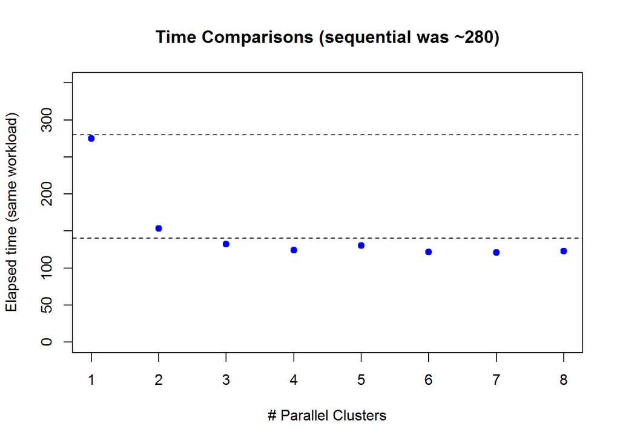

```r
plot(x=1:8, y=parNTestTime[,3], xlab="# Parallel Clusters", ylim=c(0,350), pch=19, col="blue",
     ylab="Elapsed time (same workload)",main="Time Comparisons (sequential was ~280)")
abline(h=c(140,280), lty=2)
```

Parallel processing with a single cluster seems to take roughly the same time as running sequentially. There is a substantial drop in time when moving to two clusters (this machine has two physicial cores), with much more modest drops in time when moving to 3-4 clusters (this machine has four threads / logical cores). The computer did not seem to brick when running with 4 clusters. While I tried to keep all other use of CPU to a minimum, I was able to switch between windows and “use” the computer. It did not seem to be a true brick like when running very large calculations in Excel or overflowing RAM or the like.

As expected, the move to 5 clusters actually slowed down the processing (if only by a few seconds). Upon inspection of Task Manager, the Rscript were consuming 25/25/25/13/12 of CPU; the 25/25/25 finished at almost the same time, and the 13/12 immediately jumped to 25/25.

#### *Random Forest Setup*

It may be interesting to further test these findings in an area (caret package) that includes parallel processing as part of the trainControl(). The randomForest is an ideal place to test since 1) it tends to take a long time, and 2) growing many trees using independent mtry/variables is an ideal process to piece out.

First, some machine learning data is loaded and prepped for running in the random forest:

```r
## Download data if needed
if (file.exists("pml-training.csv") & file.exists("pml-testing.csv")) {
    print("Using existing versions of pml-training.csv and pml-testing.csv")
    print(file.info("pml-training.csv")[c("size","mode","mtime")])
    print(file.info("pml-testing.csv")[c("size","mode","mtime")])
} else {
    print("Downloading versions of pml-training.csv and pml-testing.csv")
    download.file("https://d396qusza40orc.cloudfront.net/predmachlearn/pml-training.csv",
                  destfile="pml-training.csv"
                  )
    download.file("https://d396qusza40orc.cloudfront.net/predmachlearn/pml-testing.csv",
                  destfile="pml-testing.csv"
                  )
}
```

```
## [1] "Using existing versions of pml-training.csv and pml-testing.csv"
##                      size mode               mtime
## pml-training.csv 12222368  444 2016-04-20 09:58:46
##                  size mode               mtime
## pml-testing.csv 15134  444 2016-04-20 09:58:47
```

```r
## Read in CSV files
pml_training <- read.csv("pml-training.csv", stringsAsFactors=FALSE, na.strings=c("NA",""))
pml_testing <- read.csv("pml-testing.csv", stringsAsFactors=FALSE, na.strings=c("NA",""))

dim(pml_training); dim(pml_testing)
```

```
## [1] 19622   160
```

```
## [1]  20 160
```

```r
identical(names(pml_training)[1:159], names(pml_testing)[1:159])
```

```
## [1] TRUE
```

```r
print(paste0("Divergent names in column 160 are ",names(pml_training)[160],
             " in training and ",names(pml_testing)[160]," in testing"))
```

```
## [1] "Divergent names in column 160 are classe in training and problem_id in testing"
```

```r
## Load caret and randomForest, and create train/validate data
library(caret, quietly=TRUE, warn.conflicts=FALSE)
library(randomForest, quietly=TRUE, warn.conflicts=FALSE)
set.seed(0418161225)

inTrain <- createDataPartition(y=pml_training$classe, p=0.75, list=FALSE)
dfTrain <- pml_training[inTrain, ]
dfValidate <- pml_training[-inTrain, ]

dim(dfTrain); dim(dfValidate)
```

```
## [1] 14718   160
```

```
## [1] 4904  160
```

```r
table(dfTrain$classe)
```

```
##
##    A    B    C    D    E
## 4185 2848 2567 2412 2706
```

```r
## Mange the NA columns
naColSum <- colSums(is.na(dfTrain))
okCol <- which(naColSum==0) ## Use only the 0 NA columns
table(naColSum) ## All columns have either 0 NA or 14,409 (~97% of rows) NA
```

```
## naColSum
##     0 14409
##    60   100
```

```r
noNATrain <- dfTrain[,okCol] ; dim(noNATrain) ## 60 variables with no NA
```

```
## [1] 14718    60
```

```r
## Create the relevant datasets (leveraged CourseProject_v004.Rmd from folder "DS08Caret"")
badAll <- c("X", "cvtd_timestamp", "classe") ## Do not use outcome as predictor either
badStruct <- c("user_name", "raw_timestamp_part_1", "raw_timestamp_part_2", "new_window", "num_window")
smallVars <- c("roll_belt", "pitch_belt", "yaw_belt",
               "roll_forearm", "pitch_forearm", "yaw_forearm",
               "magnet_dumbbell_x", "magnet_dumbbell_y", "magnet_dumbbell_z"
               )

predictorsLimit <- noNATrain[,!(names(noNATrain) %in% c(badAll, badStruct))]
predictorsFull <- noNATrain[,!(names(noNATrain) %in% c(badAll))]
predictorsSmall <- noNATrain[,names(noNATrain) %in% c(smallVars)]
outcomes <- as.factor(noNATrain$classe) ## Factor will be easier for prediction
dim(predictorsLimit) ; dim(predictorsFull) ; dim(predictorsSmall); length(outcomes)
```

```
## [1] 14718    52
```

```
## [1] 14718    57
```

```
## [1] 14718     9
```

```
## [1] 14718
```

#### *Small Variables (Sequential)*

To simplify run times, predictorSmall will be used for the benchmarking. First, the random forest is run using both the k-fold cv and bootstrap methods, 10 times each:

```r
## Set the relevant random forest controls., explicitly ruling out parallel
bootSeqControl <- trainControl(method="boot", number=10, allowParallel = FALSE)
cvSeqControl <- trainControl(method="cv", number=10, allowParallel = FALSE)

## Run the bootstrap
baseTime <- proc.time()
rfBootSmall <- train(predictorsSmall, outcomes, method="rf", trControl=bootSeqControl)
bootSeqTime <- proc.time() - baseTime

print("Ran boostrap (number=10) sequentially in time: ")
```

```
## [1] "Ran boostrap (number=10) sequentially in time: "
```

```r
print(bootSeqTime)
```

```
##    user  system elapsed
##  280.79    6.30  288.66
```

```r
## Run the k-fold
baseTime <- proc.time()
rfCVSmall <- train(predictorsSmall, outcomes, method="rf", trControl=cvSeqControl)
cvSeqTime <- proc.time() - baseTime

print("Ran k-fold (number=10) cross-validation sequentially in time: ")
```

```
## [1] "Ran k-fold (number=10) cross-validation sequentially in time: "
```

```r
print(cvSeqTime)
```

```
##    user  system elapsed
##  251.74    6.41  259.74
```

The bootstrap and k-fold each took on the order of 4-5 minutes when run individually.

#### *Small Variables (Parallel, 2 Clusters)*

Next, we investigate the performance advantage of running in parallel with 2 clusters (which drove the overwhelming volume of the performance gains in the above timeWaster() simulations).

```r
## Set the relevant random forest controls., explicitly permitting parallel
library(parallel)
library(doParallel)
bootParControl <- trainControl(method="boot", number=10, allowParallel = TRUE)
cvParControl <- trainControl(method="cv", number=10, allowParallel = TRUE)

baseTime <- proc.time()
## Run the bootstrap, starting by setting up parallel clusters
nPars <- 2 ## Run this test with just 2 clusters (matching the 2 physical cores; see above)
clCores <- makeCluster(nPars)
registerDoParallel(clCores)

rfBootSmallPar2 <- train(predictorsSmall, outcomes, method="rf", trControl=bootParControl)

stopCluster(clCores)
registerDoSEQ()

bootParTime <- proc.time() - baseTime

print("Ran boostrap (number=10) with two parallel clusters in time: ")
```

```
## [1] "Ran boostrap (number=10) with two parallel clusters in time: "
```

```r
print(bootParTime)
```

```
##    user  system elapsed
##    9.97    0.27  172.02
```

```r
baseTime <- proc.time()
## Run the k-fold, again starting by setting up parallel clusters
nPars <- 2 ## Run this test with just 2 clusters (matching the 2 physical cores; see above)
clCores <- makeCluster(nPars)
registerDoParallel(clCores)

rfCVSmallPar2 <- train(predictorsSmall, outcomes, method="rf", trControl=cvParControl)

stopCluster(clCores)
registerDoSEQ()

cvParTime <- proc.time() - baseTime

print("Ran k-fold (number=10) cross-validation with two parallel clusters in time: ")
```

```
## [1] "Ran k-fold (number=10) cross-validation with two parallel clusters in time: "
```

```r
print(cvParTime)
```

```
##    user  system elapsed
##    9.55    0.18  158.22
```

In contrast to the timeWaster() function, the train() function has real work to do when calling the parallel clusters. In each case, parallel run times with 2 clusters are now ~60% as long as sequential run times.

#### *Small Variables (Parallel, 3 Clusters)*

Perhaps the third cluster will help in this example? Let’s see!

```r
## Set the relevant random forest controls., explicitly permitting parallel
library(parallel)
library(doParallel)
bootParControl <- trainControl(method="boot", number=10, allowParallel = TRUE)
cvParControl <- trainControl(method="cv", number=10, allowParallel = TRUE)

baseTime <- proc.time()
## Run the bootstrap, starting by setting up parallel clusters
nPars <- 3 ## Run this test 3 clusters (matching the 4 logical cores minus 1)
clCores <- makeCluster(nPars)
registerDoParallel(clCores)

rfBootSmallPar3 <- train(predictorsSmall, outcomes, method="rf", trControl=bootParControl)

stopCluster(clCores)
registerDoSEQ()

bootParTime <- proc.time() - baseTime

print("Ran boostrap (number=10) with three parallel clusters in time: ")
```

```
## [1] "Ran boostrap (number=10) with three parallel clusters in time: "
```

```r
print(bootParTime)
```

```
##    user  system elapsed
##   10.72    0.26  154.78
```

```r
baseTime <- proc.time()
## Run the k-fold, again starting by setting up parallel clusters
nPars <- 3 ## Run this test 3 clusters (matching the 4 logical cores minus 1)
clCores <- makeCluster(nPars)
registerDoParallel(clCores)

rfCVSmallPar3 <- train(predictorsSmall, outcomes, method="rf", trControl=cvParControl)

stopCluster(clCores)
registerDoSEQ()

cvParTime <- proc.time() - baseTime

print("Ran k-fold (number=10) cross-validation with three parallel clusters in time: ")
```

```
## [1] "Ran k-fold (number=10) cross-validation with three parallel clusters in time: "
```

```r
print(cvParTime)
```

```
##    user  system elapsed
##    9.65    0.28  149.40
```

There is a modest advantage, with the run times coming down by another 5%. But, it appears run times for a randomForest of complexity such that it takes 4-5 minutes to run sequentially can only be reduced by ~50% using parallel on a computer with two physical cores and four logical cores (threads).

#### *Small Variables (Accuracy Comparisons)*

Next, we compare the accuracy of the models:

```r
## Sequential
print(rfCVSmall)
```

```
## Random Forest
##
## 14718 samples
##     9 predictor
##     5 classes: 'A', 'B', 'C', 'D', 'E'
##
## No pre-processing
## Resampling: Cross-Validated (10 fold)
## Summary of sample sizes: 13246, 13245, 13245, 13248, 13246, 13247, ...
## Resampling results across tuning parameters:
##
##   mtry  Accuracy   Kappa      Accuracy SD  Kappa SD
##   2     0.9844432  0.9803265  0.005308890  0.006712051
##   5     0.9857330  0.9819576  0.004757202  0.006014377
##   9     0.9795491  0.9741342  0.006286588  0.007951013
##
## Accuracy was used to select the optimal model using  the largest value.
## The final value used for the model was mtry = 5.
```

```r
print(rfBootSmall)
```

```
## Random Forest
##
## 14718 samples
##     9 predictor
##     5 classes: 'A', 'B', 'C', 'D', 'E'
##
## No pre-processing
## Resampling: Bootstrapped (10 reps)
## Summary of sample sizes: 14718, 14718, 14718, 14718, 14718, 14718, ...
## Resampling results across tuning parameters:
##
##   mtry  Accuracy   Kappa      Accuracy SD   Kappa SD
##   2     0.9803697  0.9751614  0.0015343039  0.001931226
##   5     0.9815892  0.9767031  0.0008848788  0.001130652
##   9     0.9717252  0.9642187  0.0029550296  0.003727786
##
## Accuracy was used to select the optimal model using  the largest value.
## The final value used for the model was mtry = 5.
```

```r
confusionMatrix(predict(rfCVSmall,dfValidate[,smallVars]),dfValidate$classe)
```

```
## Confusion Matrix and Statistics
##
##           Reference
## Prediction    A    B    C    D    E
##          A 1384    9    2    0    0
##          B    9  920    9    1    3
##          C    2   16  841    4    0
##          D    0    4    3  797    0
##          E    0    0    0    2  898
##
## Overall Statistics
##
##                Accuracy : 0.9869
##                  95% CI : (0.9834, 0.9899)
##     No Information Rate : 0.2845
##     P-Value [Acc > NIR] : < 2.2e-16
##
##                   Kappa : 0.9835
##  Mcnemar's Test P-Value : NA
##
## Statistics by Class:
##
##                      Class: A Class: B Class: C Class: D Class: E
## Sensitivity            0.9921   0.9694   0.9836   0.9913   0.9967
## Specificity            0.9969   0.9944   0.9946   0.9983   0.9995
## Pos Pred Value         0.9921   0.9766   0.9745   0.9913   0.9978
## Neg Pred Value         0.9969   0.9927   0.9965   0.9983   0.9993
## Prevalence             0.2845   0.1935   0.1743   0.1639   0.1837
## Detection Rate         0.2822   0.1876   0.1715   0.1625   0.1831
## Detection Prevalence   0.2845   0.1921   0.1760   0.1639   0.1835
## Balanced Accuracy      0.9945   0.9819   0.9891   0.9948   0.9981
```

```r
confusionMatrix(predict(rfBootSmall,dfValidate[,smallVars]),dfValidate$classe)
```

```
## Confusion Matrix and Statistics
##
##           Reference
## Prediction    A    B    C    D    E
##          A 1383    8    2    0    0
##          B    9  921    8    1    4
##          C    3   17  843    4    0
##          D    0    3    2  797    0
##          E    0    0    0    2  897
##
## Overall Statistics
##
##                Accuracy : 0.9872
##                  95% CI : (0.9836, 0.9901)
##     No Information Rate : 0.2845
##     P-Value [Acc > NIR] : < 2.2e-16
##
##                   Kappa : 0.9838
##  Mcnemar's Test P-Value : NA
##
## Statistics by Class:
##
##                      Class: A Class: B Class: C Class: D Class: E
## Sensitivity            0.9914   0.9705   0.9860   0.9913   0.9956
## Specificity            0.9972   0.9944   0.9941   0.9988   0.9995
## Pos Pred Value         0.9928   0.9767   0.9723   0.9938   0.9978
## Neg Pred Value         0.9966   0.9929   0.9970   0.9983   0.9990
## Prevalence             0.2845   0.1935   0.1743   0.1639   0.1837
## Detection Rate         0.2820   0.1878   0.1719   0.1625   0.1829
## Detection Prevalence   0.2841   0.1923   0.1768   0.1635   0.1833
## Balanced Accuracy      0.9943   0.9825   0.9900   0.9950   0.9975
```

```r
## Parallel 2 clusters
print(rfCVSmallPar2)
```

```
## Random Forest
##
## 14718 samples
##     9 predictor
##     5 classes: 'A', 'B', 'C', 'D', 'E'
##
## No pre-processing
## Resampling: Cross-Validated (10 fold)
## Summary of sample sizes: 13245, 13247, 13245, 13247, 13247, 13245, ...
## Resampling results across tuning parameters:
##
##   mtry  Accuracy   Kappa      Accuracy SD  Kappa SD
##   2     0.9841021  0.9798956  0.003326390  0.004203770
##   5     0.9861402  0.9824727  0.003296002  0.004166150
##   9     0.9798894  0.9745662  0.003168839  0.004007007
##
## Accuracy was used to select the optimal model using  the largest value.
## The final value used for the model was mtry = 5.
```

```r
print(rfBootSmallPar2)
```

```
## Random Forest
##
## 14718 samples
##     9 predictor
##     5 classes: 'A', 'B', 'C', 'D', 'E'
##
## No pre-processing
## Resampling: Bootstrapped (10 reps)
## Summary of sample sizes: 14718, 14718, 14718, 14718, 14718, 14718, ...
## Resampling results across tuning parameters:
##
##   mtry  Accuracy   Kappa      Accuracy SD  Kappa SD
##   2     0.9807458  0.9755999  0.002922303  0.003720255
##   5     0.9825375  0.9778704  0.002273550  0.002885936
##   9     0.9737288  0.9667104  0.005042428  0.006384771
##
## Accuracy was used to select the optimal model using  the largest value.
## The final value used for the model was mtry = 5.
```

```r
confusionMatrix(predict(rfCVSmallPar2,dfValidate[,smallVars]),dfValidate$classe)
```

```
## Confusion Matrix and Statistics
##
##           Reference
## Prediction    A    B    C    D    E
##          A 1383    8    2    0    0
##          B    9  921    7    1    3
##          C    2   16  845    3    0
##          D    1    4    1  798    0
##          E    0    0    0    2  898
##
## Overall Statistics
##
##                Accuracy : 0.988
##                  95% CI : (0.9845, 0.9908)
##     No Information Rate : 0.2845
##     P-Value [Acc > NIR] : < 2.2e-16
##
##                   Kappa : 0.9848
##  Mcnemar's Test P-Value : NA
##
## Statistics by Class:
##
##                      Class: A Class: B Class: C Class: D Class: E
## Sensitivity            0.9914   0.9705   0.9883   0.9925   0.9967
## Specificity            0.9972   0.9949   0.9948   0.9985   0.9995
## Pos Pred Value         0.9928   0.9787   0.9758   0.9925   0.9978
## Neg Pred Value         0.9966   0.9929   0.9975   0.9985   0.9993
## Prevalence             0.2845   0.1935   0.1743   0.1639   0.1837
## Detection Rate         0.2820   0.1878   0.1723   0.1627   0.1831
## Detection Prevalence   0.2841   0.1919   0.1766   0.1639   0.1835
## Balanced Accuracy      0.9943   0.9827   0.9916   0.9955   0.9981
```

```r
confusionMatrix(predict(rfBootSmallPar2,dfValidate[,smallVars]),dfValidate$classe)
```

```
## Confusion Matrix and Statistics
##
##           Reference
## Prediction    A    B    C    D    E
##          A 1383    9    2    0    0
##          B    9  918    8    1    3
##          C    3   17  844    3    0
##          D    0    5    1  798    0
##          E    0    0    0    2  898
##
## Overall Statistics
##
##                Accuracy : 0.9872
##                  95% CI : (0.9836, 0.9901)
##     No Information Rate : 0.2845
##     P-Value [Acc > NIR] : < 2.2e-16
##
##                   Kappa : 0.9838
##  Mcnemar's Test P-Value : NA
##
## Statistics by Class:
##
##                      Class: A Class: B Class: C Class: D Class: E
## Sensitivity            0.9914   0.9673   0.9871   0.9925   0.9967
## Specificity            0.9969   0.9947   0.9943   0.9985   0.9995
## Pos Pred Value         0.9921   0.9776   0.9735   0.9925   0.9978
## Neg Pred Value         0.9966   0.9922   0.9973   0.9985   0.9993
## Prevalence             0.2845   0.1935   0.1743   0.1639   0.1837
## Detection Rate         0.2820   0.1872   0.1721   0.1627   0.1831
## Detection Prevalence   0.2843   0.1915   0.1768   0.1639   0.1835
## Balanced Accuracy      0.9941   0.9810   0.9907   0.9955   0.9981
```

```r
## Parallel 3 clusters
print(rfCVSmallPar3)
```

```
## Random Forest
##
## 14718 samples
##     9 predictor
##     5 classes: 'A', 'B', 'C', 'D', 'E'
##
## No pre-processing
## Resampling: Cross-Validated (10 fold)
## Summary of sample sizes: 13244, 13247, 13246, 13247, 13247, 13247, ...
## Resampling results across tuning parameters:
##
##   mtry  Accuracy   Kappa      Accuracy SD  Kappa SD
##   2     0.9838286  0.9795510  0.006408749  0.008096615
##   5     0.9858673  0.9821265  0.004772385  0.006034066
##   9     0.9802282  0.9749941  0.005211064  0.006589474
##
## Accuracy was used to select the optimal model using  the largest value.
## The final value used for the model was mtry = 5.
```

```r
print(rfBootSmallPar3)
```

```
## Random Forest
##
## 14718 samples
##     9 predictor
##     5 classes: 'A', 'B', 'C', 'D', 'E'
##
## No pre-processing
## Resampling: Bootstrapped (10 reps)
## Summary of sample sizes: 14718, 14718, 14718, 14718, 14718, 14718, ...
## Resampling results across tuning parameters:
##
##   mtry  Accuracy   Kappa      Accuracy SD  Kappa SD
##   2     0.9799581  0.9746707  0.001798283  0.002258964
##   5     0.9811987  0.9762376  0.002138187  0.002696980
##   9     0.9704798  0.9626882  0.004185929  0.005282916
##
## Accuracy was used to select the optimal model using  the largest value.
## The final value used for the model was mtry = 5.
```

```r
confusionMatrix(predict(rfCVSmallPar3,dfValidate[,smallVars]),dfValidate$classe)
```

```
## Confusion Matrix and Statistics
##
##           Reference
## Prediction    A    B    C    D    E
##          A 1384    7    2    0    0
##          B    9  920    8    1    3
##          C    2   17  844    4    0
##          D    0    5    1  797    0
##          E    0    0    0    2  898
##
## Overall Statistics
##
##                Accuracy : 0.9876
##                  95% CI : (0.9841, 0.9905)
##     No Information Rate : 0.2845
##     P-Value [Acc > NIR] : < 2.2e-16
##
##                   Kappa : 0.9843
##  Mcnemar's Test P-Value : NA
##
## Statistics by Class:
##
##                      Class: A Class: B Class: C Class: D Class: E
## Sensitivity            0.9921   0.9694   0.9871   0.9913   0.9967
## Specificity            0.9974   0.9947   0.9943   0.9985   0.9995
## Pos Pred Value         0.9935   0.9777   0.9735   0.9925   0.9978
## Neg Pred Value         0.9969   0.9927   0.9973   0.9983   0.9993
## Prevalence             0.2845   0.1935   0.1743   0.1639   0.1837
## Detection Rate         0.2822   0.1876   0.1721   0.1625   0.1831
## Detection Prevalence   0.2841   0.1919   0.1768   0.1637   0.1835
## Balanced Accuracy      0.9948   0.9821   0.9907   0.9949   0.9981
```

```r
confusionMatrix(predict(rfBootSmallPar3,dfValidate[,smallVars]),dfValidate$classe)
```

```
## Confusion Matrix and Statistics
##
##           Reference
## Prediction    A    B    C    D    E
##          A 1384    7    2    0    0
##          B    9  919    8    1    3
##          C    2   19  843    2    0
##          D    0    4    2  799    0
##          E    0    0    0    2  898
##
## Overall Statistics
##
##                Accuracy : 0.9876
##                  95% CI : (0.9841, 0.9905)
##     No Information Rate : 0.2845
##     P-Value [Acc > NIR] : < 2.2e-16
##
##                   Kappa : 0.9843
##  Mcnemar's Test P-Value : NA
##
## Statistics by Class:
##
##                      Class: A Class: B Class: C Class: D Class: E
## Sensitivity            0.9921   0.9684   0.9860   0.9938   0.9967
## Specificity            0.9974   0.9947   0.9943   0.9985   0.9995
## Pos Pred Value         0.9935   0.9777   0.9734   0.9925   0.9978
## Neg Pred Value         0.9969   0.9924   0.9970   0.9988   0.9993
## Prevalence             0.2845   0.1935   0.1743   0.1639   0.1837
## Detection Rate         0.2822   0.1874   0.1719   0.1629   0.1831
## Detection Prevalence   0.2841   0.1917   0.1766   0.1642   0.1835
## Balanced Accuracy      0.9948   0.9815   0.9901   0.9962   0.9981
```

The results are observed to all be substantially the same. Interestingly:

- Bootstrap and CV (assuming each run with 10) both drive ~98.8% accuracy with the holdout data
- Bootstrap tends to self-estimate a lower accuracy during modeling and to increase during validation
- CV tends to self-estimate a similar accuracy during modeling and validation
- These may all be artifcats of the current dataset and variables selected

The accuracy data are also extracted for plotting:

```r
rfCVAcc <- round(rfCVSmall$results[rfCVSmall$result$mtry==rfCVSmall$bestTune[[1]],],3)
rfBootAcc <- round(rfBootSmall$results[rfBootSmall$result$mtry==rfBootSmall$bestTune[[1]],],3)

rfCVAccPar2 <- round(rfCVSmallPar2$results[rfCVSmallPar2$result$mtry==rfCVSmallPar2$bestTune[[1]],],3)
rfBootAccPar2 <- round(rfBootSmallPar2$results[rfBootSmallPar2$result$mtry==rfBootSmallPar2$bestTune[[1]],],3)

rfCVAccPar3 <- round(rfCVSmallPar3$results[rfCVSmallPar3$result$mtry==rfCVSmallPar3$bestTune[[1]],],3)
rfBootAccPar3 <- round(rfBootSmallPar3$results[rfBootSmallPar3$result$mtry==rfBootSmallPar3$bestTune[[1]],],3)

modAcc <- rbind(rfCVAcc, rfCVAccPar2, rfCVAccPar3, rfBootAcc, rfBootAccPar2, rfBootAccPar3)
modAcc
```

```
##    mtry Accuracy Kappa AccuracySD KappaSD
## 2     5    0.986 0.982      0.005   0.006
## 21    5    0.986 0.982      0.003   0.004
## 22    5    0.986 0.982      0.005   0.006
## 23    5    0.982 0.977      0.001   0.001
## 24    5    0.983 0.978      0.002   0.003
## 25    5    0.981 0.976      0.002   0.003
```

```r
rfCVCon <- round(caret::confusionMatrix(predict(rfCVSmall, dfValidate[,smallVars]),
                                        dfValidate$classe
                                        )$overall[c(1,3:5)],3)
rfBootCon <- round(caret::confusionMatrix(predict(rfBootSmall, dfValidate[,smallVars]),
                                          dfValidate$classe
                                         )$overall[c(1,3:5)],3)

rfCVConPar2 <- round(caret::confusionMatrix(predict(rfCVSmallPar2, dfValidate[,smallVars]),
                                            dfValidate$classe
                                            )$overall[c(1,3:5)],3)
rfBootConPar2 <- round(caret::confusionMatrix(predict(rfBootSmallPar2, dfValidate[,smallVars]),
                                              dfValidate$classe
                                             )$overall[c(1,3:5)],3)

rfCVConPar3 <- round(caret::confusionMatrix(predict(rfCVSmallPar3, dfValidate[,smallVars]),
                                            dfValidate$classe
                                            )$overall[c(1,3:5)],3)
rfBootConPar3 <- round(caret::confusionMatrix(predict(rfBootSmallPar3, dfValidate[,smallVars]),
                                              dfValidate$classe
                                             )$overall[c(1,3:5)],3)

modCon <- rbind(rfCVCon, rfCVConPar2, rfCVConPar3, rfBootCon, rfBootConPar2, rfBootConPar3)
modCon
```

```
##               Accuracy AccuracyLower AccuracyUpper AccuracyNull
## rfCVCon          0.987         0.983         0.990        0.284
## rfCVConPar2      0.988         0.985         0.991        0.284
## rfCVConPar3      0.988         0.984         0.990        0.284
## rfBootCon        0.987         0.984         0.990        0.284
## rfBootConPar2    0.987         0.984         0.990        0.284
## rfBootConPar3    0.988         0.984         0.990        0.284
```

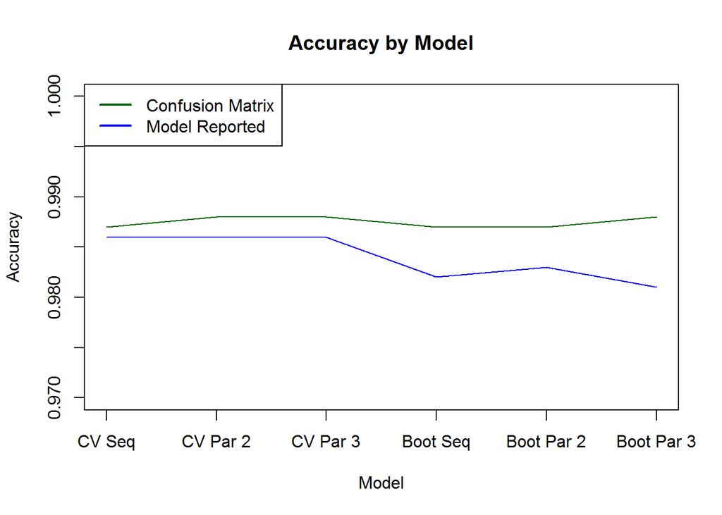

```r
plot(x=1:6, y=modAcc[,2], ylab="Accuracy", main="Accuracy by Model",
     ylim=c(0.97,1), type="l", col="blue", xaxt="n", xlab="Model")
axis(1, at=1:6, labels=c("CV Seq", "CV Par 2", "CV Par 3", "Boot Seq", "Boot Par 2", "Boot Par 3"))
lines(x=1:6, y=modCon[,1], col="dark green")
legend("topleft", legend=c("Confusion Matrix","Model Reported"), lwd=2, col=c("dark green","blue"))
```

As expected, there is no obvious impact on accuracy when switching to parallel.

#### *Larger Variables (Sequential and 2-3 Parallel Clusters)*

Next, run times are compared for a more complicated model with most of the variables. This time, the model uses only method=“cv” and number=10.

```r
## Set the relevant random forest controls., explicitly ruling out parallel
cvSeqControl <- trainControl(method="cv", number=10, allowParallel = FALSE)

## Run the k-fold
baseTime <- proc.time()
rfCVLimit <- train(predictorsLimit, outcomes, method="rf", trControl=cvSeqControl)
cvSeqTime <- proc.time() - baseTime

print("Ran k-fold (number=10) cross-validation sequentially in time: ")
```

```
## [1] "Ran k-fold (number=10) cross-validation sequentially in time: "
```

```r
print(cvSeqTime)
```

```
##    user  system elapsed
## 1502.77    6.46 1521.09
```

The process is then re-run using a 2-cluster parallel process:

```r
## Set the relevant random forest controls., explicitly permitting parallel
library(parallel)
library(doParallel)
cvParControl <- trainControl(method="cv", number=10, allowParallel = TRUE)

baseTime <- proc.time()
## Run the k-fold, starting by setting up parallel clusters
nPars <- 2 ## Run this test with just 2 clusters (matching the 2 physical cores; see above)
clCores <- makeCluster(nPars)
registerDoParallel(clCores)

rfCVLimitPar2 <- train(predictorsLimit, outcomes, method="rf", trControl=cvParControl)

stopCluster(clCores)
registerDoSEQ()

cvParTime <- proc.time() - baseTime

print("Ran k-fold (number=10) cross-validation with two parallel clusters in time: ")
```

```
## [1] "Ran k-fold (number=10) cross-validation with two parallel clusters in time: "
```

```r
print(cvParTime)
```

```
##    user  system elapsed
##   40.43    0.22 1027.98
```

Run time is reduced by ~33% when using 2 clusters, suggesting there is significant time involved in splitting out jobs and then reintegrating them. Perhaps that makes 3 clusters more important here - let’s see:

```r
## Set the relevant random forest controls., explicitly permitting parallel
library(parallel)
library(doParallel)
cvParControl <- trainControl(method="cv", number=10, allowParallel = TRUE)

baseTime <- proc.time()
## Run the k-fold, starting by setting up parallel clusters
nPars <- 3 ## Run this test with just 2 clusters (matching the 2 physical cores; see above)
clCores <- makeCluster(nPars)
registerDoParallel(clCores)

rfCVLimitPar3 <- train(predictorsLimit, outcomes, method="rf", trControl=cvParControl)

stopCluster(clCores)
registerDoSEQ()

cvParTime <- proc.time() - baseTime

print("Ran k-fold (number=10) cross-validation with three parallel clusters in time: ")
```

```
## [1] "Ran k-fold (number=10) cross-validation with three parallel clusters in time: "
```

```r
print(cvParTime)
```

```
##    user  system elapsed
##   38.54    0.24  878.89
```

The 3-cluster approach runs in ~55% of the time of the sequential approach. It seems that the third cluster is more valuable here than in the timeWaster() example, partly since the second cluster was less impactful.